# Meta-analysis physiological costs of hibernation: Report 6 - Arousal GC

Pablo Capilla-Lasheras

2025-04-07

This [R Markdown](http://rmarkdown.rstudio.com) Notebook contains the initial meta-analysis for the project ‘physiological ’costs’ of hibernation.

## Dataset and calculation of effect sizes

The dataset for this meta-analysis has been collected after a literature search by Pablo Burraco, Marko Prokic and Tamara Petrovic. It contains data on physiological effects of hibernation in different systems. Here a quick snapshot of the first lines of the dataset:

|  | Reference | Year | Study_ID | Species | Family | Genus | Common.name | Type_of_animal | Thermoregulation | Class | Class_2 | Ver_Invert | Developmental_stage | Location | Experiment_venue | Biological.process | Tissue | Experimental_manipulation | Sex | Cortisol_or_corticosterone | Unit | Euthermia_N | Euthermia_M | Euthermia_SD | Euthermia_SE | Hib_N | Hib_M | Hib_SD | Hib_SE | … |
| --- | --- | --- | --- | --- | --- | --- | --- | --- | --- | --- | --- | --- | --- | --- | --- | --- | --- | --- | --- | --- | --- | --- | --- | --- | --- | --- | --- | --- | --- | --- |
| 1 | Dauphin-Villemant et al 1990 | 1990 | Study_765 | Zootoca vivipara | Lacertidae | Zootoca | Common lizard | Lizard | Ectotherm | Reptilia | NA | Vertebrate | Adult | France | Laboratory | Hibernation | Plasma | NA | Female | Corticosterone | ng/mL | 15 | 25.931034 | NA | 2.9425287 | 5 | 57.380224 | NA | 23.960234 | … |
| 2 | Dauphin-Villemant et al 1990 | 1990 | Study_765 | Zootoca vivipara | Lacertidae | Zootoca | Common lizard | Lizard | Ectotherm | Reptilia | NA | Vertebrate | Adult | France | Laboratory | Hibernation | Plasma | NA | Female | Corticosterone | ng/mL | 15 | 25.931034 | NA | 2.9425287 | 5 | 50.408159 | NA | 9.082635 | … |
| 3 | Dauphin-Villemant et al 1990 | 1990 | Study_765 | Zootoca vivipara | Lacertidae | Zootoca | Common lizard | Lizard | Ectotherm | Reptilia | NA | Vertebrate | Adult | France | Laboratory | Hibernation | Plasma | NA | Female | Corticosterone | ng/mL | 15 | 25.931034 | NA | 2.9425287 | 5 | 63.332944 | NA | 17.775081 | … |
| 4 | Dauphin-Villemant et al 1990 | 1990 | Study_765 | Zootoca vivipara | Lacertidae | Zootoca | Common lizard | Lizard | Ectotherm | Reptilia | NA | Vertebrate | Adult | France | Laboratory | Hibernation | Plasma | NA | Female | Corticosterone | ng/mL | 15 | 25.931034 | NA | 2.9425287 | 5 | 32.125271 | NA | 11.013979 | … |
| 5 | Dauphin-Villemant et al 1990 | 1990 | Study_765 | Zootoca vivipara | Lacertidae | Zootoca | Common lizard | Lizard | Ectotherm | Reptilia | NA | Vertebrate | Adult | France | Laboratory | Hibernation | Plasma | NA | Female | Corticosterone | ng/mL | 15 | 25.931034 | NA | 2.9425287 | 5 | 19.804439 | NA | 2.707055 | … |
| 6 | Dauphin-Villemant et al 1990 | 1990 | Study_765 | Zootoca vivipara | Lacertidae | Zootoca | Common lizard | Lizard | Ectotherm | Reptilia | NA | Vertebrate | Adult | France | Laboratory | Hibernation | Plasma | NA | Female | Corticosterone | ng/mL | 15 | 25.931034 | NA | 2.9425287 | 5 | 33.429325 | NA | 7.729108 | … |
| 7 | Dauphin-Villemant et al 1990 | 1990 | Study_765 | Zootoca vivipara | Lacertidae | Zootoca | Common lizard | Lizard | Ectotherm | Reptilia | NA | Vertebrate | Adult | France | Laboratory | Hibernation | Plasma | NA | Female | Corticosterone | ng/mL | 15 | 25.931034 | NA | 2.9425287 | 5 | 41.195402 | NA | 6.068966 | … |
| 8 | Dauphin-Villemant et al 1990 | 1990 | Study_765 | Zootoca vivipara | Lacertidae | Zootoca | Common lizard | Lizard | Ectotherm | Reptilia | NA | Vertebrate | Adult | France | Laboratory | Hibernation | Plasma | NA | Female | Corticosterone | ng/mL | 15 | 25.931034 | NA | 2.9425287 | 5 | 62.712644 | NA | 4.965517 | … |
| 9 | Dauphin-Villemant et al 1990 | 1990 | Study_765 | Zootoca vivipara | Lacertidae | Zootoca | Common lizard | Lizard | Ectotherm | Reptilia | NA | Vertebrate | Adult | France | Laboratory | Hibernation | Plasma | NA | Female | Corticosterone | ng/mL | 15 | 25.931034 | NA | 2.9425287 | 12 | 75.954023 | NA | 6.620690 | … |
| 10 | Dauphin-Villemant et al 1990 | 1990 | Study_765 | Zootoca vivipara | Lacertidae | Zootoca | Common lizard | Lizard | Ectotherm | Reptilia | NA | Vertebrate | Adult | France | Laboratory | Hibernation | Plasma | NA | Female | Corticosterone | ng/mL | 15 | 25.931034 | NA | 2.9425287 | 5 | 57.563218 | NA | 13.977011 | … |

[output cut: 108 more lines]

As a summary of the *initial dataset*:

- Number of studies: 19
- Number of species: 16

For this meta-analysis, I am going to include all glucocorticoid (GC) measures and calculate the standarised mean difference as the effect size of analysis comparing **arousal** *versus* **euthermia**. Positive SMD values indicate higher GC values in *arousal* while negative SMD indicate lower GC values in *arousal*. This is a summary of the effect size calculation based on the dataset above:

Summary of SMD effect size and number of observations included in the meta-analysis:

```
##     Min.  1st Qu.   Median     Mean  3rd Qu.     Max.
## -2.76323 -1.05404 -0.35289 -0.03781  0.79233  4.16865
```

- Number of observation with non-missing SMD: 28
- Number of studies in the dataset for analysis: 6
- Number of species in the dataset for analysis: 5

## Initial meta-analysis:

```r
model_SMD <- rma.mv(yi = SMDH_arousal,
                    V = SMDH.sv_arousal,
                    mods = ~ 1,
                    random = list(~1|Study_ID,
                                  #~1|Class,
                                  ~1|Family,
                                  ~1|Species,
                                  ~1|obsID),
                    data=df_SMD,
                    method="REML")
```

```
##
## Multivariate Meta-Analysis Model (k = 28; method: REML)
##
##   logLik  Deviance       AIC       BIC      AICc
## -49.0607   98.1214  108.1214  114.6006  110.9785
##
## Variance Components:
##
##             estim    sqrt  nlvls  fixed    factor
## sigma^2.1  0.0000  0.0003      6     no  Study_ID
## sigma^2.2  0.1081  0.3288      5     no    Family
## sigma^2.3  0.1081  0.3288      5     no   Species
## sigma^2.4  1.3780  1.1739     28     no     obsID
##
## Test for Heterogeneity:
## Q(df = 27) = 107.3505, p-val < .0001
##
## Model Results:
##
## estimate      se     zval    pval    ci.lb   ci.ub
##  -0.2509  0.3609  -0.6951  0.4870  -0.9582  0.4565
##
## ---
## Signif. codes:  0 '***' 0.001 '**' 0.01 '*' 0.05 '.' 0.1 ' ' 1
```

Proportion of variation left after accounting for sampling variance and proportion accounted by each random effect:

| Variable | i2_value_percentage |
| --- | --- |
| I2_Total | 83.828 |
| I2_Study_ID | 0.000 |
| I2_Family | 5.685 |
| I2_Species | 5.685 |
| I2_obsID | 72.458 |

### Plot of results of intercept-only model:

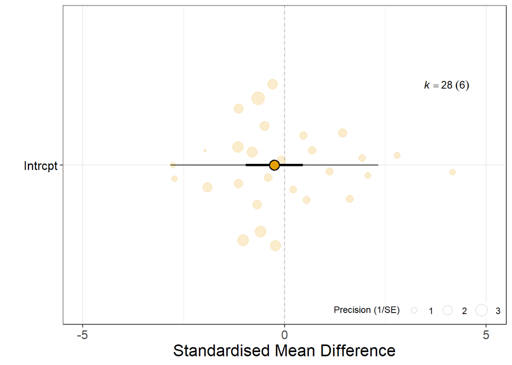

### Publication bias: small-study effects

```
##
## Multivariate Meta-Analysis Model (k = 28; method: REML)
##
##   logLik  Deviance       AIC       BIC      AICc
## -47.6943   95.3885  109.3885  118.1952  115.6108
##
## Variance Components:
##
##             estim    sqrt  nlvls  fixed    factor
## sigma^2.1  0.0156  0.1247      6     no  Study_ID
## sigma^2.2  0.0000  0.0006      2     no     Class
## sigma^2.3  0.1349  0.3672      5     no    Family
## sigma^2.4  0.1349  0.3672      5     no   Species
## sigma^2.5  1.4447  1.2020     28     no     obsID
##
## Test for Residual Heterogeneity:
## QE(df = 26) = 104.0519, p-val < .0001
##
## Test of Moderators (coefficient 2):
## QM(df = 1) = 0.0198, p-val = 0.8881
##
## Model Results:
##
##                   estimate      se     zval    pval    ci.lb   ci.ub
## intrcpt            -0.4712  1.4977  -0.3146  0.7531  -3.4066  2.4642
## sqrt(inv_eff_ss)    0.4014  2.8535   0.1407  0.8881  -5.1914  5.9941
##
## ---
## Signif. codes:  0 '***' 0.001 '**' 0.01 '*' 0.05 '.' 0.1 ' ' 1
```

```
##    R2_marginal R2_conditional
##    0.001059643    0.165797507
```

### Publication bias: time-lag effects

```
##
## Multivariate Meta-Analysis Model (k = 28; method: REML)
##
##   logLik  Deviance       AIC       BIC      AICc
## -47.4412   94.8825  108.8825  117.6891  115.1047
##
## Variance Components:
##
##             estim    sqrt  nlvls  fixed    factor
## sigma^2.1  0.1653  0.4065      6     no  Study_ID
## sigma^2.2  0.0001  0.0073      2     no     Class
## sigma^2.3  0.0000  0.0010      5     no    Family
## sigma^2.4  0.0000  0.0010      5     no   Species
## sigma^2.5  1.4619  1.2091     28     no     obsID
##
## Test for Residual Heterogeneity:
## QE(df = 26) = 105.7557, p-val < .0001
##
## Test of Moderators (coefficient 2):
## QM(df = 1) = 0.4727, p-val = 0.4917
##
## Model Results:
##
##              estimate      se     zval    pval    ci.lb   ci.ub
## intrcpt       -0.1728  0.3571  -0.4839  0.6285  -0.8728  0.5272
## scale(Year)   -0.2197  0.3195  -0.6876  0.4917  -0.8459  0.4065
##
## ---
## Signif. codes:  0 '***' 0.001 '**' 0.01 '*' 0.05 '.' 0.1 ' ' 1
```

```
##    R2_marginal R2_conditional
##     0.02880223     0.12748305
```

## Meta-analysis including thermoregulation type as a moderator:

Number of observations for each type:

```
##
## Ectotherm Endotherm
##        20         8
```

```
##
## Multivariate Meta-Analysis Model (k = 28; method: REML)
##
##   logLik  Deviance       AIC       BIC      AICc
## -47.3493   94.6986  108.6986  117.5052  114.9208
##
## Variance Components:
##
##             estim    sqrt  nlvls  fixed    factor
## sigma^2.1  0.0000  0.0003      6     no  Study_ID
## sigma^2.2  0.3360  0.5797      2     no     Class
## sigma^2.3  0.1141  0.3378      5     no    Family
## sigma^2.4  0.1141  0.3378      5     no   Species
## sigma^2.5  1.4696  1.2123     28     no     obsID
##
## Test for Residual Heterogeneity:
## QE(df = 26) = 107.1761, p-val < .0001
##
## Test of Moderators (coefficients 1:2):
## QM(df = 2) = 0.4458, p-val = 0.8002
##
## Model Results:
##
##                            estimate      se     zval    pval    ci.lb   ci.ub
## ThermoregulationEctotherm   -0.0589  0.7487  -0.0787  0.9373  -1.5264  1.4085
## ThermoregulationEndotherm   -0.5500  0.8295  -0.6630  0.5073  -2.1757  1.0758
##
## ThermoregulationEctotherm
## ThermoregulationEndotherm
##
## ---
## Signif. codes:  0 '***' 0.001 '**' 0.01 '*' 0.05 '.' 0.1 ' ' 1
```

```
##
## Multivariate Meta-Analysis Model (k = 28; method: REML)
##
##   logLik  Deviance       AIC       BIC      AICc
## -47.3493   94.6986  108.6986  117.5052  114.9208
##
## Variance Components:
##
##             estim    sqrt  nlvls  fixed    factor
## sigma^2.1  0.0000  0.0003      6     no  Study_ID
## sigma^2.2  0.3360  0.5797      2     no     Class
## sigma^2.3  0.1141  0.3378      5     no    Family
## sigma^2.4  0.1141  0.3378      5     no   Species
## sigma^2.5  1.4696  1.2123     28     no     obsID
##
## Test for Residual Heterogeneity:
## QE(df = 26) = 107.1761, p-val < .0001
##
## Test of Moderators (coefficients 1:2):
## QM(df = 2) = 0.4458, p-val = 0.8002
##
## Model Results:
##
##                            estimate      se     zval    pval    ci.lb   ci.ub
## ThermoregulationEctotherm   -0.0589  0.7487  -0.0787  0.9373  -1.5264  1.4085
## ThermoregulationEndotherm   -0.5500  0.8295  -0.6630  0.5073  -2.1757  1.0758
##
## ThermoregulationEctotherm
## ThermoregulationEndotherm
##
## ---
## Signif. codes:  0 '***' 0.001 '**' 0.01 '*' 0.05 '.' 0.1 ' ' 1
```

### Plot of results of thermoregulation meta-regression:

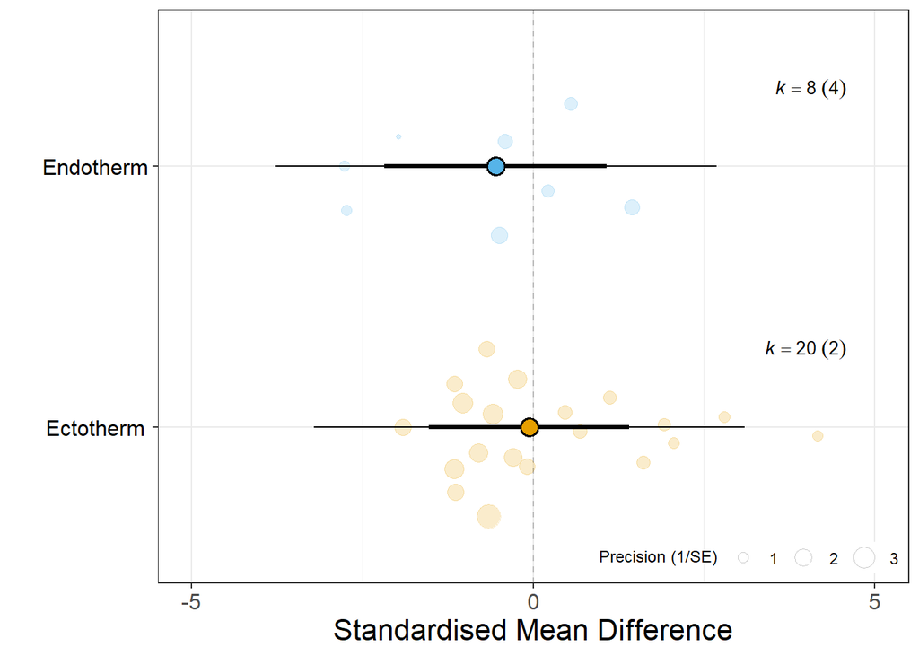